# Simulated data documentation

Steve and Jonathan

2019-12-24

- Latent variable approach
- Matrix based approach (known covariances and correlations)

## Latent variable approach

The main idea is to simulate both measured and unmeasured covariates from a given distribution with know parameters. For simplicity, we consider only one measured covariate $(x)$ and one unmeasured covariate $(x')$.

We assume that the availability of services at time $t$ depends on availability at time $t-1$ and simulate the two covariates as a first-order autoregressive, AR(1), process:

$$x_{ht} = \overline{x}_{ht} + \phi x_{ht-1} + \epsilon_{ht}$$

and

$$x'_{ht} = \overline{x}'_{ht} + \phi' x'_{ht-1} + \epsilon_{ht}$$

Where:

$$|\phi|, |\phi'| < 1\\
\epsilon_{ht} \sim \mathit{N}(0, \sigma^2)\\
\overline{x}_{ht} \sim \mathit{N}(0, \sigma^2_{Asympt})\\
\overline{x}'_{ht} \sim \mathit{N}(0, \sigma^2_{Asympt})\\
\sigma^2_{Asympt} = \frac{\sigma^2}{1 - \phi^2}$$

- $\phi$ and $\sigma^2_{Asympt}$ are the slope defining the autocorrelation at lag 1 and the theoretical variance of the AR(1) process, respectively.
- $x_{ht}$ and $x'_{ht}$ are the measured and unmeasured covariates for household $h$ at time $t$.

Let $\beta'_{1}$ and $\beta_{1}$ be the effect sizes of unmeasured and measured covariates defined above. Define linear predictor for a given service for household $h$ at time $t$ as

$$\eta_{ht} = \beta'_{1}x'_{ht} + \beta_{1}x_{ht} + \epsilon_{h}$$

- $\epsilon_{h}$ are the household random effects such that

$$\epsilon_{h} \sim \mathit{N}(0, \sigma)$$

The household services for the time period $t + 1$ are generated using *switch* probabilities. Let $\beta_{lose}$ be the odd of losing service and $\beta_{gain}$ be the odd of gaining service, switch probabilities are either defined in a:

- **mechanistic way**
  - If the household, $h$, has service, $s$, at the current time, $t$ i.e., $y_{hts} = 1$, then the odd of losing service in $t+1$ is $\mu_{hts} = \beta_{lose} - \eta_{hts}$. The switch probability is given by
    $$\pi_{ht} = \frac{1}{1 + \exp{(-\mu_{hts})}}$$
  - Otherwise, if $y_{hts} = 0$, the odd of gaining service in the next year is $\mu'_{hts} = \beta_{gain} + \eta_{hts}$ with a switch probability of
    $$\pi_{ht} = \frac{1}{1 + \exp{(-\mu'_{hts})}}$$
- **simplified (or statistical) way**
  - The odd of household $h$ at time $t$ gaining service $s$ is defined as
    $$\mu_{hts} = \eta_{hts} + \beta_{gain} + \beta_{add}\mu_{ht-1,s}\\
    \beta_{add} = -(\beta_{gain} + \beta_{lose}).$$
    Thus, switch probability is defined as
    $$\pi_{hts} = \frac{1}{1 + \exp{(-\mu_{hts})}}$$
  - $\mu_{hts}$, $t = 0$ can be chosen at random

For this task, we use the simplified approach since we established that the two approaches give the same results.

Thus for households $s$ at time $t$, the observed value for service $s$ is drawn from a binomial distribution i.e.,
$$y_{hts} \sim \mathit{Bin}(1, \pi_{hts}).$$

We simulated observed values for two services $(s = \{1,2\})$ for $5000$ households running for $100$ years and excluded the first $20$ years from the analysis (to take care of stationarity of the AR(1) process).

### Fitting method

Two approaches were used to fit the model:

- **Separate models**: Fit two separate models for each of the services and compare the estimates with the true values. Results from these models are not shown in this writeup.
- **Joint models**: Fit a multivariate mixed model for binary outcomes in `glmer` using method described by Ben Bolker (see [here](https://mac-theobio.github.io/QMEE/MultivariateMixed.html)). We can as well use Bayesian fitting interfaces but these might be very slow especially when comparing across multiple simulations.

#### Model

We fit an intercept only multivariate random effect model with two binary variable responses which indicate whether or not a given household has improved services in a particular year. In what we term as *stepback* method, we restructure the data and use include status (0/1) in the previous year to predict the service status in the current year. In particular, the fixed terms are availability of the service in the previous year and wealth index while the random term has a correlated, time-independent variation among the households

$$logit(p(y_{hts} = 1)) = \beta_{0,hts} + \beta_{1,s} y_{ht-1,s} + \beta_{2,s} x\\
\beta_{0,hts} = \beta_0 + \alpha_{0,hts} \\
\alpha_{0,hts} \sim \mathit{N}(0, \sigma^2_s).$$

Where:

- $\beta_{0, hts}$ is the baseline odds of households gaining service
- $\beta_{1,s}$ is the overall effect size of improved service in the previous year on status of service in the current year (odds of gaining service in the current year)
- $\beta_{2,s}$ is the overall effect size of household income (measure covariate, x) on the status of service
- $\alpha_{0,hts}$ captures the offset of household odds of gaining service from the overall baseline (mean)

### Results

The parameters were estimated from a multivariate model.

#### Fixed effects

Figure 1 shows results for service 1 while Figure 2 shows results for service 2.

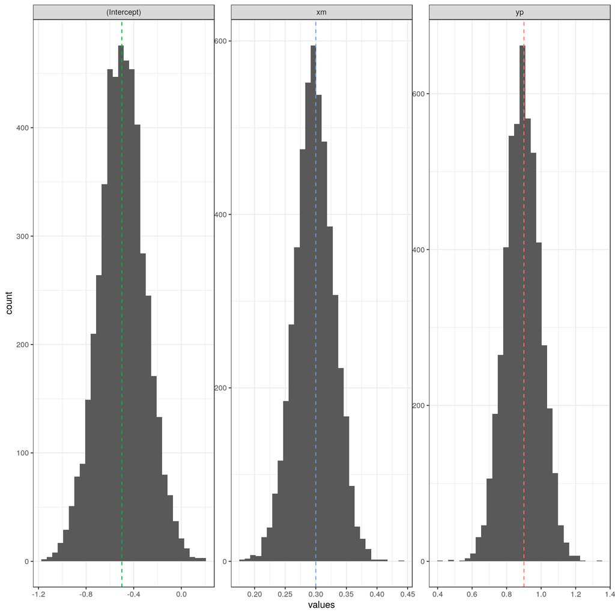

Figure 1: Service 1

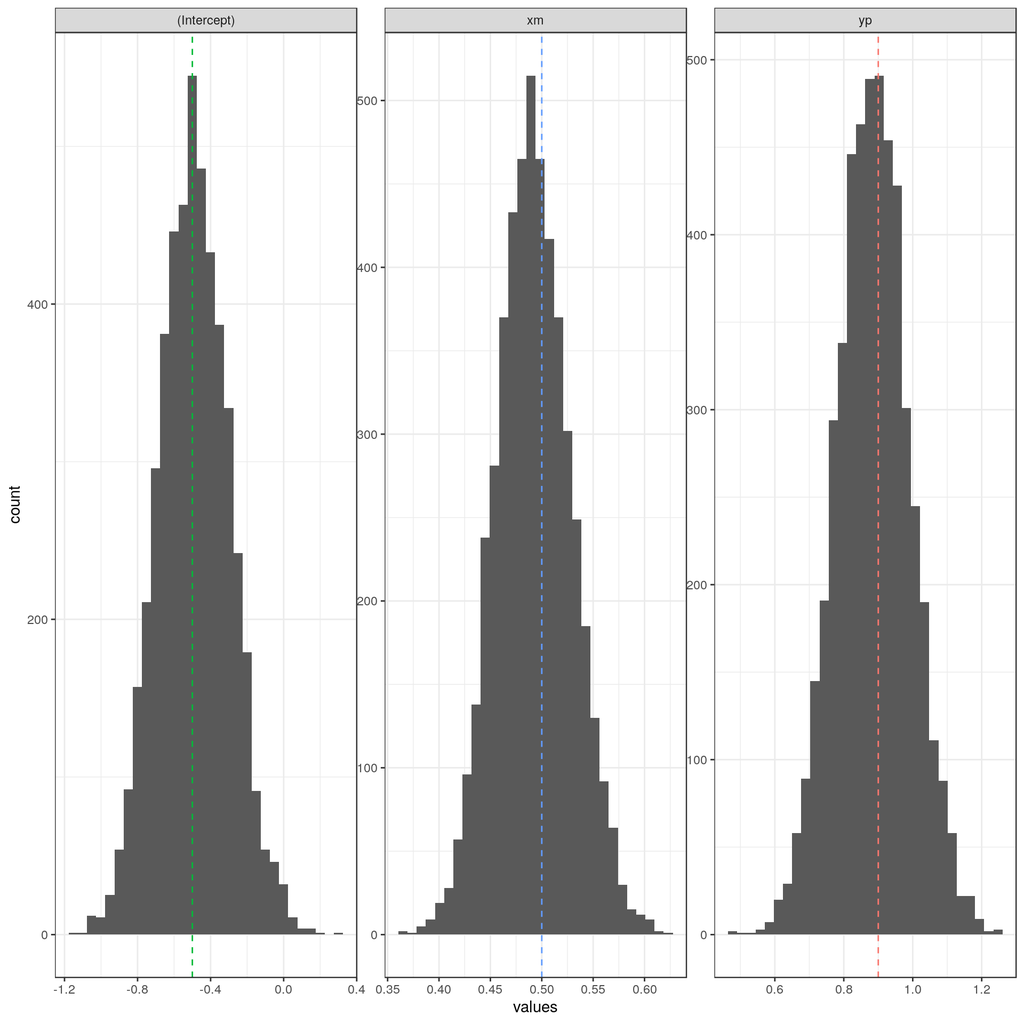

Figure 2: Service 2

#### Checkplots

Steve: JD any reference or more description?

Basically used to check how good our estimates are. We expect uniformly distributed `p-values` (piano plot?)

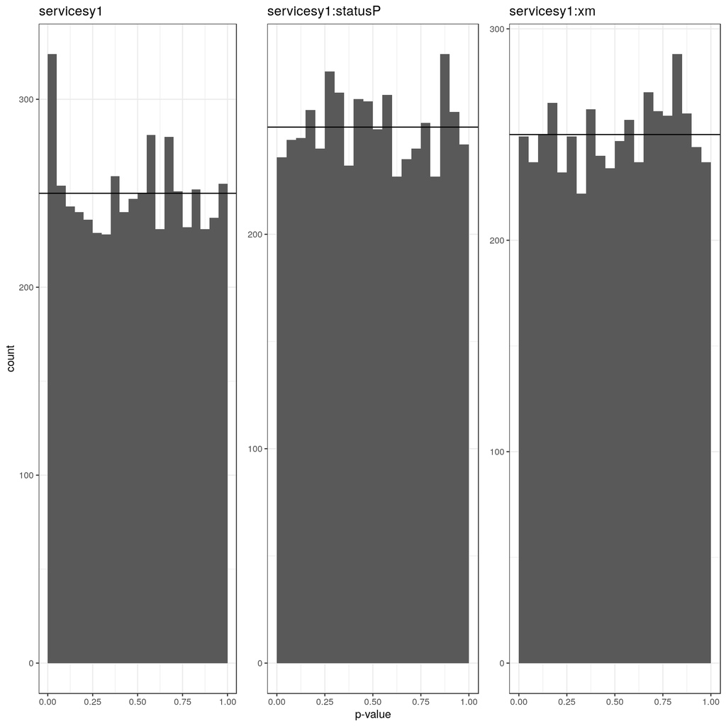

Figure 3: Service 1 piano plots

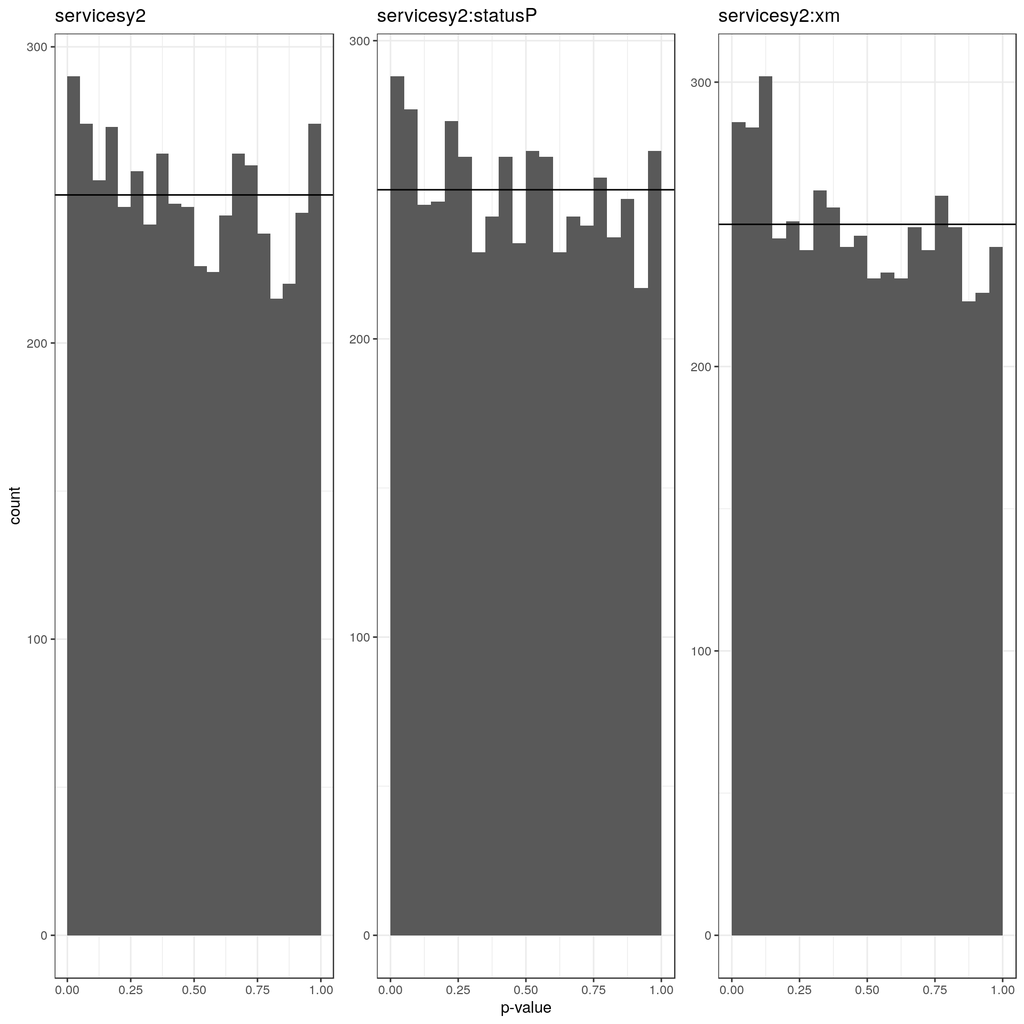

Figure 4: Service 2 piano plots